# Mikolaj Wojtysiak-Wawrzyniak Lab6

## Mikołaj Wojtysiak-Wawrzyniak 239114

### 1.

```python
import numpy as np
import arviz as az
import pymc3 as pm
import matplotlib.pyplot as plt
import warnings
warnings.filterwarnings('ignore')
```

[output not shown]

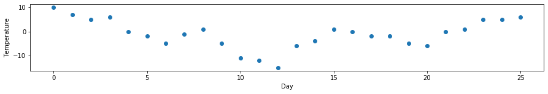

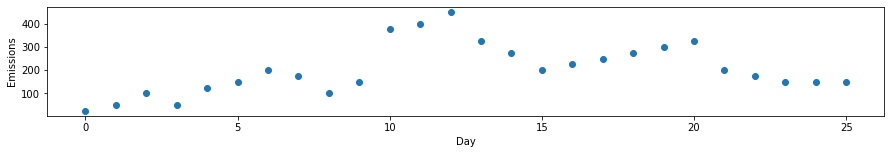

```python
plt.rcParams['figure.figsize'] = [15, 2]
temperatures = np.array([10, 7, 5, 6, 0, -2, -5, -1, 1, -5, -11, -12, -15, -6, -4, 1, 0, -2, -2, -5, -6, 0, 1, 5, 5, 6])
emissions = np.array([25, 50, 100, 50, 125, 150, 200, 175, 100, 150, 375, 400, 450, 325, 275, 200, 225, 250, 275, 300, 325, 200, 175, 150, 150, 150])
plt.scatter(np.arange(len(temperatures)), temperatures)
plt.xlabel("Day")
plt.ylabel("Temperature")
plt.show()
plt.scatter(np.arange(len(emissions)), emissions)
plt.xlabel("Day")
plt.ylabel("Emissions")
plt.show()
```

```
-16.958X + 186.854
```

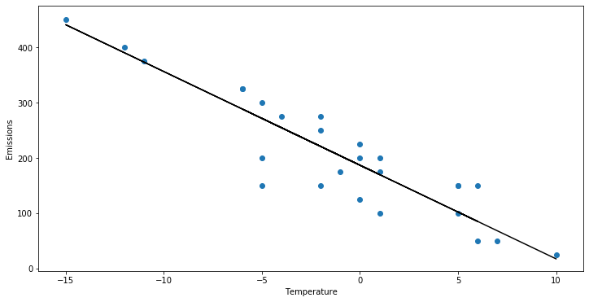

```python
plt.rcParams['figure.figsize'] = [12, 6]

ls_coef_ = np.cov(temperatures, emissions)[0,1]/np.var(temperatures)
ls_intercept = emissions.mean() - ls_coef_*temperatures.mean()
print(f"{ls_coef_:.3f}X + {ls_intercept:.3f}")
plt.plot(temperatures, ls_coef_*temperatures + ls_intercept, label ="Least-squares prediction", color='k')
plt.scatter(temperatures, emissions)
plt.xlabel("Temperature")
plt.ylabel("Emissions")
plt.show()
```

```python
with pm.Model() as model:
    b= pm.Uniform("b", lower=-100, upper=100)
    m_e= pm.Deterministic("m_e", b*15-b*temperatures)
    sigma_e= pm.Uniform("sigma_e", lower=0.1, upper=100)
    emission = pm.Normal("emission", mu=m_e, sigma=sigma_e, observed=emissions)
    idata= pm.sample(2000, tune=2500)
```

```
Auto-assigning NUTS sampler...
Initializing NUTS using jitter+adapt_diag...
Multiprocess sampling (4 chains in 4 jobs)
NUTS: [sigma_e, b]
```

100.00% [18000/18000 01:12<00:00 Sampling 4 chains, 0 divergences]

```
Sampling 4 chains for 2_500 tune and 2_000 draw iterations (10_000 + 8_000 draws total) took 81 seconds.
```

```
array([<matplotlib.axes._subplots.AxesSubplot object at 0x000001FFCB8B2A60>,
      dtype=object)
```

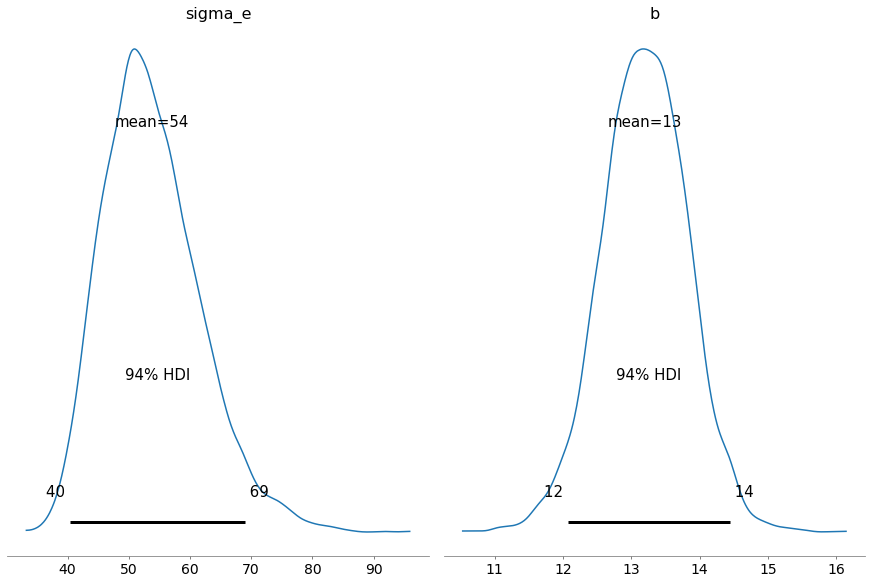

```python
az.plot_posterior(idata, var_names=["sigma_e", "b"], figsize=[12, 8])
```

```python
with pm.Model() as model:
    b_1 = pm.Uniform("b_1", lower=-100, upper=100)
    b_2 = pm.Uniform("b_2", lower=-100, upper=100)
    tau = pm.DiscreteUniform("tau", lower=0, upper=len(temperatures) -1)
    idx= np.arange(len(temperatures))
    b = pm.math.switch(tau > idx, b_1, b_2)
    m_e= pm.Deterministic("m_e", b*15-b*temperatures)

    sigma_e= pm.Uniform("sigma_e", lower=0.1, upper=100)
    emission = pm.Normal("emission", mu=m_e, sigma=sigma_e, observed=emissions)
    idata= pm.sample(2000, tune=2500)
```

```
Multiprocess sampling (4 chains in 4 jobs)
CompoundStep
>NUTS: [sigma_e, b_2, b_1]
>Metropolis: [tau]
```

100.00% [18000/18000 01:44<00:00 Sampling 4 chains, 0 divergences]

```
Sampling 4 chains for 2_500 tune and 2_000 draw iterations (10_000 + 8_000 draws total) took 113 seconds.
```

```
array([<matplotlib.axes._subplots.AxesSubplot object at 0x000001FFCD71B100>,
      dtype=object)
```

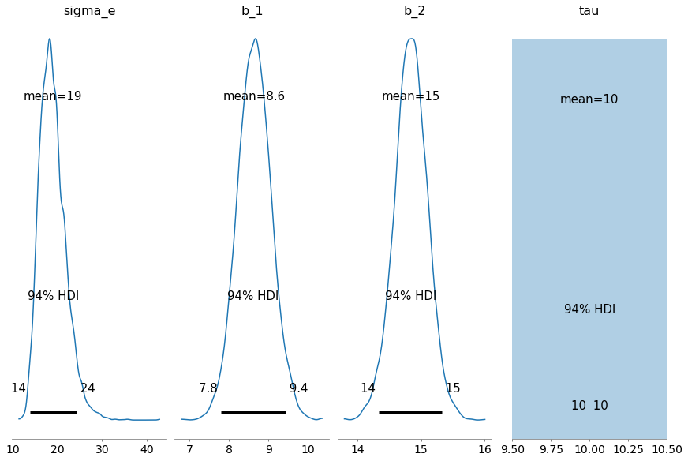

```python
az.plot_posterior(idata, var_names=["sigma_e", "b_1", "b_2", "tau"], figsize=[12, 8])
```

```
-16.958X + 186.854
```

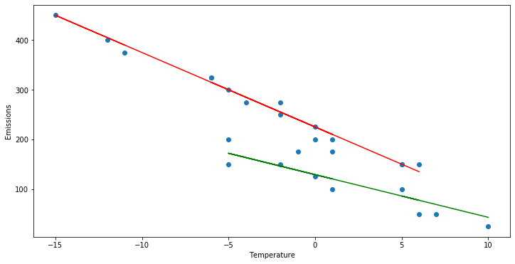

```python
ls_coef_ = np.cov(temperatures, emissions)[0,1]/np.var(temperatures)
ls_intercept = emissions.mean() - ls_coef_*temperatures.mean()
print(f"{ls_coef_:.3f}X + {ls_intercept:.3f}")
#plt.plot(temperatures, ls_coef_*temperatures + ls_intercept, label ="Least-squares prediction", color='k')
plt.scatter(temperatures, emissions)
plt.plot(temperatures[:10], 8.6 * (15 - temperatures[:10]), color='g')
plt.plot(temperatures[10:], 15 * (15 - temperatures[10:]), color='r')
plt.xlabel("Temperature")
plt.ylabel("Emissions")
plt.show()
```

Scenario:

Every month you tank your new car and drive it for the whole month. At the end of the month, you note down the kilometers travelled and liters tanked. After some time you feel that the fuel consumption has increased - you try to determine the moment when the fuel consumption increased - maybe it will be covered in the warrany.

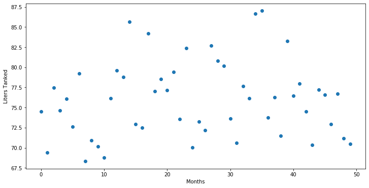

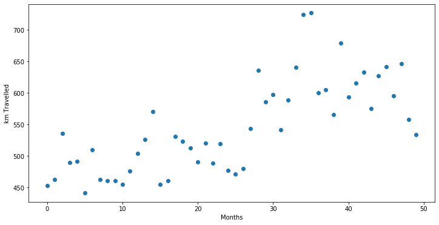

```
8.696X + -115.179
```

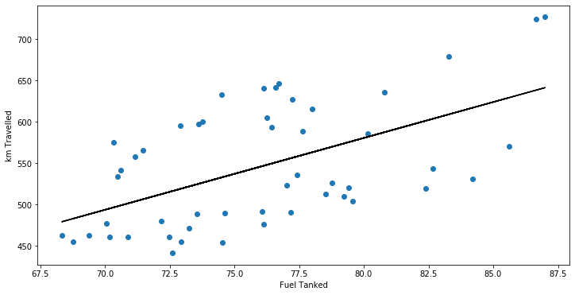

```python
from numpy.random import normal as nr
fuel_cons_1 = 6.5
fuel_cons_2 = 8

b1 = 0
b2 = 0

days = 50
change = 28

fuel_tanked = np.random.normal(loc=75, scale=5, size=(days,))

km_travelled = np.concatenate((
    (fuel_cons_1 + nr(scale=0.3, size = (fuel_tanked[:change].shape)))* fuel_tanked[:change] + b1 ,
    (fuel_cons_2 + nr(scale=0.3, size = (fuel_tanked[change:].shape)))* fuel_tanked[change:] + b2
))

plt.plot(fuel_tanked, 'o')
plt.xlabel("Months")
plt.ylabel("Liters Tanked")
plt.show()

plt.plot(km_travelled, 'o')
plt.xlabel("Months")
plt.ylabel("km Travelled")
plt.show()

plt.scatter(fuel_tanked, km_travelled)
ls_coef_ = np.cov(fuel_tanked, km_travelled)[0,1]/np.var(fuel_tanked)
ls_intercept = km_travelled.mean() - ls_coef_*fuel_tanked.mean()
print(f"{ls_coef_:.3f}X + {ls_intercept:.3f}")
plt.plot(fuel_tanked, ls_coef_*fuel_tanked + ls_intercept, label ="Least-squares prediction", color='k')
plt.xlabel("Fuel Tanked")
plt.ylabel("km Travelled")
plt.show()
```

```python
with pm.Model() as model:
    a= pm.Uniform("a", lower=-10, upper=10)
    m_cons= pm.Deterministic("m_cons", a*fuel_tanked)
    sigma_cons= pm.Uniform("sigma_cons", lower=0.01, upper=10000)
    cons = pm.Normal("fuel_consumption", mu=m_cons, sigma=sigma_cons, observed=km_travelled)
    idata= pm.sample(2000, tune=2500)
```

```
Auto-assigning NUTS sampler...
Initializing NUTS using jitter+adapt_diag...
Multiprocess sampling (4 chains in 4 jobs)
NUTS: [sigma_cons, a]
```

100.00% [18000/18000 01:09<00:00 Sampling 4 chains, 0 divergences]

```
Sampling 4 chains for 2_500 tune and 2_000 draw iterations (10_000 + 8_000 draws total) took 78 seconds.
```

```
array([<matplotlib.axes._subplots.AxesSubplot object at 0x000001FFCAEDA850>,
      dtype=object)
```

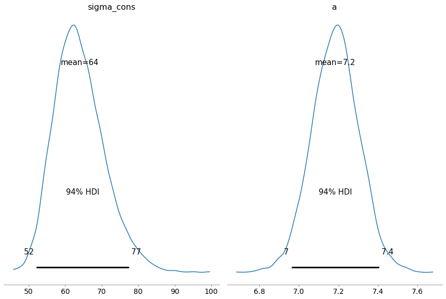

```python
az.plot_posterior(idata, var_names=["sigma_cons", "a"], figsize=[12, 8])
```

```python
with pm.Model() as model:
    a_1 = pm.Uniform("a_1", lower=-10, upper=10)
    a_2 = pm.Uniform("a_2", lower=-10, upper=10)
    tau = pm.DiscreteUniform("tau", lower=0, upper=len(fuel_tanked)-1)
    idx= np.arange(len(fuel_tanked))
    a = pm.math.switch(tau > idx, a_1, a_2)
    m_cons= pm.Deterministic("m_cons", a*fuel_tanked)

    sigma_cons= pm.Uniform("sigma_cons", lower=0.1, upper=10000)
    cons = pm.Normal("fuel_consumption", mu=m_cons, sigma=sigma_cons, observed=km_travelled)
    idata= pm.sample(2000, tune=2500)
```

```
Multiprocess sampling (4 chains in 4 jobs)
CompoundStep
>NUTS: [sigma_cons, a_2, a_1]
>Metropolis: [tau]
```

100.00% [18000/18000 01:40<00:00 Sampling 4 chains, 0 divergences]

```
Sampling 4 chains for 2_500 tune and 2_000 draw iterations (10_000 + 8_000 draws total) took 108 seconds.
```

```
array([<matplotlib.axes._subplots.AxesSubplot object at 0x000001FFCD9AAD90>,
      dtype=object)
```

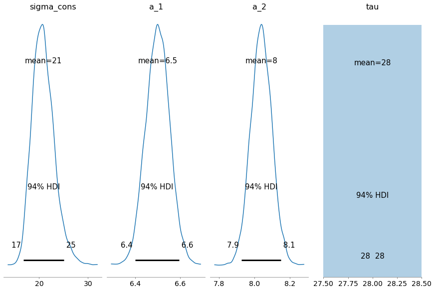

```python
az.plot_posterior(idata, var_names=["sigma_cons", "a_1", "a_2", "tau"], figsize=[12, 8])
```

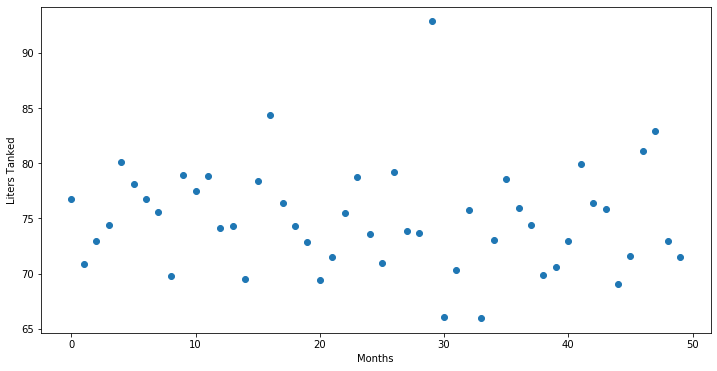

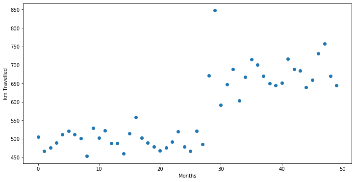

```
6.871X + 61.093
```

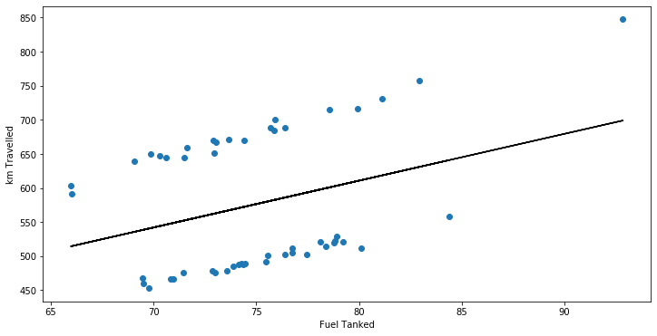

```python
from numpy.random import normal as nr
fuel_cons_1 = 6.5
fuel_cons_2 = 9

b1 = 5
b2 = 5

days = 50
change = 28

fuel_tanked = np.random.normal(loc=75, scale=5, size=(days,))

km_travelled = np.concatenate((
    (fuel_cons_1 + nr(scale=0.1, size = (fuel_tanked[:change].shape)))* fuel_tanked[:change] + b1 ,
    (fuel_cons_2 + nr(scale=0.1, size = (fuel_tanked[change:].shape)))* fuel_tanked[change:] + b1
))

plt.plot(fuel_tanked, 'o')
plt.xlabel("Months")
plt.ylabel("Liters Tanked")
plt.show()

plt.plot(km_travelled, 'o')
plt.xlabel("Months")
plt.ylabel("km Travelled")
plt.show()

plt.scatter(fuel_tanked, km_travelled)
ls_coef_ = np.cov(fuel_tanked, km_travelled)[0,1]/np.var(fuel_tanked)
ls_intercept = km_travelled.mean() - ls_coef_*fuel_tanked.mean()
print(f"{ls_coef_:.3f}X + {ls_intercept:.3f}")
plt.plot(fuel_tanked, ls_coef_*fuel_tanked + ls_intercept, label ="Least-squares prediction", color='k')
plt.xlabel("Fuel Tanked")
plt.ylabel("km Travelled")
plt.show()
```

```python
with pm.Model() as model:
    a_1 = pm.Uniform("a_1", lower=-10, upper=10)
    a_2 = pm.Uniform("a_2", lower=-10, upper=10)
    tau = pm.DiscreteUniform("tau", lower=0, upper=len(fuel_tanked)-1)
    idx= np.arange(len(fuel_tanked))
    a = pm.math.switch(tau > idx, a_1, a_2)
    m_cons= pm.Deterministic("m_cons", a*fuel_tanked)

    sigma_cons= pm.Uniform("sigma_cons", lower=0.1, upper=10000)
    cons = pm.Normal("fuel_consumption", mu=m_cons, sigma=sigma_cons, observed=km_travelled)
    idata= pm.sample(2000, tune=2500)
```

```
Multiprocess sampling (4 chains in 4 jobs)
CompoundStep
>NUTS: [sigma_cons, a_2, a_1]
>Metropolis: [tau]
```

100.00% [18000/18000 01:49<00:00 Sampling 4 chains, 0 divergences]

```
Sampling 4 chains for 2_500 tune and 2_000 draw iterations (10_000 + 8_000 draws total) took 117 seconds.
```

```
array([<matplotlib.axes._subplots.AxesSubplot object at 0x000001FFCDD024C0>,
      dtype=object)
```

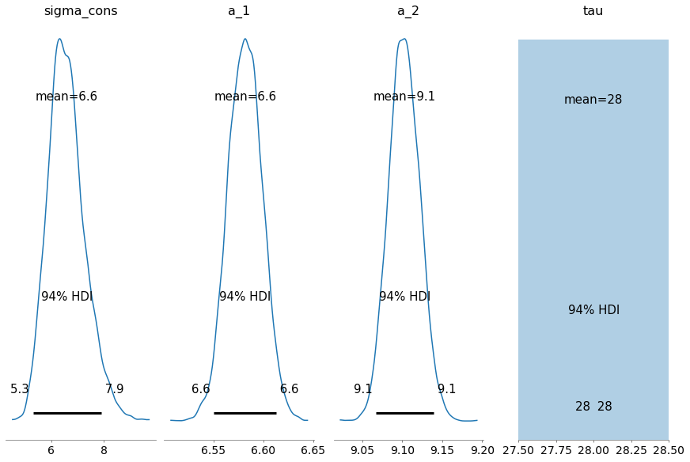

```python
az.plot_posterior(idata, var_names=["sigma_cons", "a_1", "a_2", "tau"], figsize=[12, 8])
```

## Higher noise values

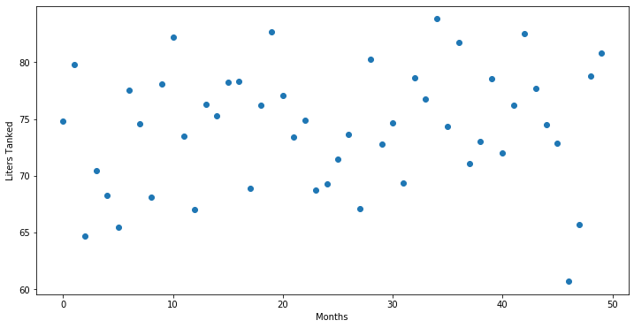

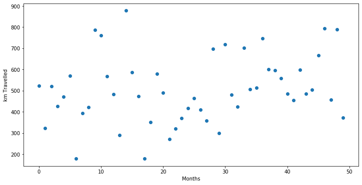

```
5.068X + 130.016
```

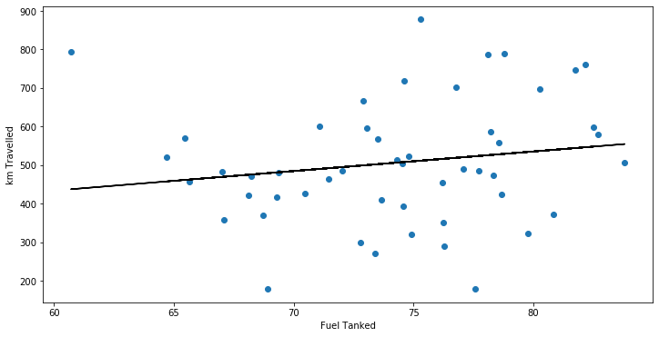

```python
from numpy.random import normal as nr
fuel_cons_1 = 6.5
fuel_cons_2 = 8

b1 = 0
b2 = 0

days = 50
change = 28

fuel_tanked = np.random.normal(loc=75, scale=5, size=(days,))

km_travelled = np.concatenate((
    (fuel_cons_1 + nr(scale=2, size = (fuel_tanked[:change].shape)))* fuel_tanked[:change] + b1 ,
    (fuel_cons_2 + nr(scale=2, size = (fuel_tanked[change:].shape)))* fuel_tanked[change:] + b2
))

plt.plot(fuel_tanked, 'o')
plt.xlabel("Months")
plt.ylabel("Liters Tanked")
plt.show()

plt.plot(km_travelled, 'o')
plt.xlabel("Months")
plt.ylabel("km Travelled")
plt.show()

plt.scatter(fuel_tanked, km_travelled)
ls_coef_ = np.cov(fuel_tanked, km_travelled)[0,1]/np.var(fuel_tanked)
ls_intercept = km_travelled.mean() - ls_coef_*fuel_tanked.mean()
print(f"{ls_coef_:.3f}X + {ls_intercept:.3f}")
plt.plot(fuel_tanked, ls_coef_*fuel_tanked + ls_intercept, label ="Least-squares prediction", color='k')
plt.xlabel("Fuel Tanked")
plt.ylabel("km Travelled")
plt.show()
```

```python
with pm.Model() as model:
    a_1 = pm.Uniform("a_1", lower=-10, upper=10)
    a_2 = pm.Uniform("a_2", lower=-10, upper=10)
    tau = pm.DiscreteUniform("tau", lower=0, upper=len(fuel_tanked)-1)
    idx= np.arange(len(fuel_tanked))
    a = pm.math.switch(tau > idx, a_1, a_2)
    m_cons= pm.Deterministic("m_cons", a*fuel_tanked)

    sigma_cons= pm.Uniform("sigma_cons", lower=0.1, upper=10000)
    cons = pm.Normal("fuel_consumption", mu=m_cons, sigma=sigma_cons, observed=km_travelled)
    idata= pm.sample(2000, tune=2500)
```

```
Multiprocess sampling (4 chains in 4 jobs)
CompoundStep
>NUTS: [sigma_cons, a_2, a_1]
>Metropolis: [tau]
```

100.00% [18000/18000 03:18<00:00 Sampling 4 chains, 67 divergences]

```
Sampling 4 chains for 2_500 tune and 2_000 draw iterations (10_000 + 8_000 draws total) took 207 seconds.
There were 67 divergences after tuning. Increase `target_accept` or reparameterize.
The acceptance probability does not match the target. It is 0.5581371183475302, but should be close to 0.8. Try to increase the number of tuning steps.
The acceptance probability does not match the target. It is 0.8838858873757011, but should be close to 0.8. Try to increase the number of tuning steps.
The acceptance probability does not match the target. It is 0.9556771563376247, but should be close to 0.8. Try to increase the number of tuning steps.
The acceptance probability does not match the target. It is 0.9416114596245564, but should be close to 0.8. Try to increase the number of tuning steps.
The number of effective samples is smaller than 10% for some parameters.
```

```
array([<matplotlib.axes._subplots.AxesSubplot object at 0x000001FFCD4B4670>,
      dtype=object)
```

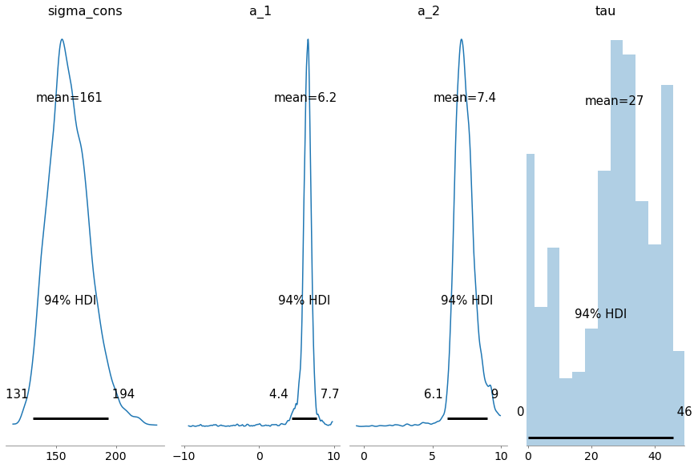

```python
az.plot_posterior(idata, var_names=["sigma_cons", "a_1", "a_2", "tau"], figsize=[12, 8])
```

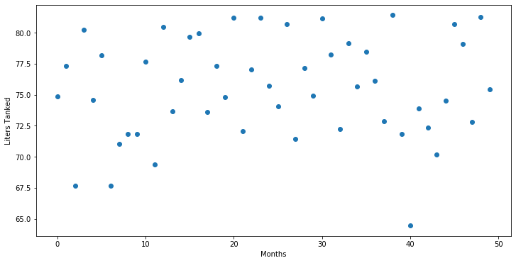

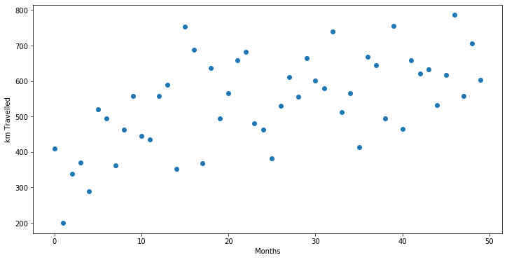

```
4.705X + 186.254
```

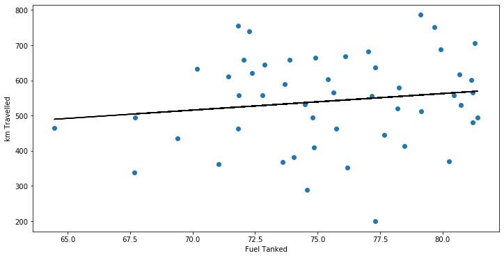

```python
from numpy.random import normal as nr
fuel_cons_1 = 6.5
fuel_cons_2 = 8

b1 = 0
b2 = 0

days = 50
change = 28

fuel_tanked = np.random.normal(loc=75, scale=5, size=(days,))

km_travelled = np.concatenate((
    (fuel_cons_1 +        nr(scale=1.5, size = (fuel_tanked[:change-8].shape)))* fuel_tanked[:change-8] + b1 ,
    (fuel_cons_1 + 0.25 + nr(scale=1.5, size = (fuel_tanked[change-8:change-6].shape)))* fuel_tanked[change-8:change-6] + b1 ,
    (fuel_cons_1 + 0.50 + nr(scale=1.5, size = (fuel_tanked[change-6:change-4].shape)))* fuel_tanked[change-6:change-4] + b1 ,
    (fuel_cons_1 + 0.75 + nr(scale=1.5, size = (fuel_tanked[change-4:change-2].shape)))* fuel_tanked[change-4:change-2] + b1 ,
    (fuel_cons_1 + 1.00 + nr(scale=1.5, size = (fuel_tanked[change-2:change].shape)))* fuel_tanked[change-2:change] + b1 ,
    (fuel_cons_2 + nr(scale=1.5, size = (fuel_tanked[change:].shape)))* fuel_tanked[change:] + b2
))

plt.plot(fuel_tanked, 'o')
plt.xlabel("Months")
plt.ylabel("Liters Tanked")
plt.show()

plt.plot(km_travelled, 'o')
plt.xlabel("Months")
plt.ylabel("km Travelled")
plt.show()

plt.scatter(fuel_tanked, km_travelled)
ls_coef_ = np.cov(fuel_tanked, km_travelled)[0,1]/np.var(fuel_tanked)
ls_intercept = km_travelled.mean() - ls_coef_*fuel_tanked.mean()
print(f"{ls_coef_:.3f}X + {ls_intercept:.3f}")
plt.plot(fuel_tanked, ls_coef_*fuel_tanked + ls_intercept, label ="Least-squares prediction", color='k')
plt.xlabel("Fuel Tanked")
plt.ylabel("km Travelled")
plt.show()
```

```python
with pm.Model() as model:
    a_1 = pm.Uniform("a_1", lower=-10, upper=10)
    a_2 = pm.Uniform("a_2", lower=-10, upper=10)
    tau = pm.DiscreteUniform("tau", lower=0, upper=len(fuel_tanked)-1)
    idx= np.arange(len(fuel_tanked))
    a = pm.math.switch(tau > idx, a_1, a_2)
    m_cons= pm.Deterministic("m_cons", a*fuel_tanked)

    sigma_cons= pm.Uniform("sigma_cons", lower=0.1, upper=10000)
    cons = pm.Normal("fuel_consumption", mu=m_cons, sigma=sigma_cons, observed=km_travelled)
    idata= pm.sample(2000, tune=2500)
```

```
Multiprocess sampling (4 chains in 4 jobs)
CompoundStep
>NUTS: [sigma_cons, a_2, a_1]
>Metropolis: [tau]
```

100.00% [18000/18000 01:53<00:00 Sampling 4 chains, 0 divergences]

```
Sampling 4 chains for 2_500 tune and 2_000 draw iterations (10_000 + 8_000 draws total) took 122 seconds.
The estimated number of effective samples is smaller than 200 for some parameters.
```

```
array([<matplotlib.axes._subplots.AxesSubplot object at 0x000001FFCAFA1FD0>,
      dtype=object)
```

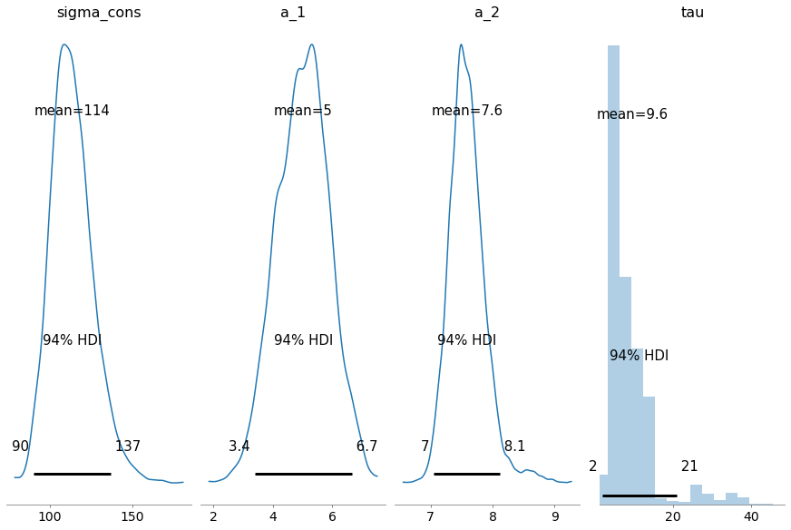

```python
az.plot_posterior(idata, var_names=["sigma_cons", "a_1", "a_2", "tau"], figsize=[12, 8])
```

In this excercise, we observe the data, that we assume follows a linear function. In one point in time, we suspect that something has changed - the coefficient of linear function has increased.

First we check the linear model - we can see that the standard deviation (sigma) is very high - indicating that the prediction is poor. And in fact we can see that the line does not represent the data well, since the original data is composed of essentially 2 functions - one linear up to a switch point, then a second linear.

To approximate it better we use two functions with variable switch point. We feed that to the model and obtain correct predictions - two linear coefficient and the switch poinnt is calculated automatically.

Second excericse was to propose our own scenario, fabricate the data and make the same predictions. My scenario was

#### Scenario:

##### Every month you tank your new car and drive it for the whole month. At the end of the month, you note down the kilometers travelled and liters tanked. After some time you feel that the fuel consumption has increased - you try to determine the moment when the fuel consumption increased - maybe it will be covered in the warrany.

Having this data I prepared a similar model with two linear coefficients and a variable switching point. The switch point was predicted accurately and the slopes of the lines matched the data I prepared. However, due to the data, the sigma was still quite high

Then, I tried to increase the noise. As expected, more noise led to much poorer prediction, affecting both slopes (a_1, a_2), sigma and even the switch point